# network_analyses

2025-07-08

## 1. Network overview

Let’s get an idea of the the school network. Here I am using the data from the file “edgelist.csv”, where I have directed nominations for 2 categories: “good friends” and “best friends”. I build 2 networks: 1 for “good friends” (Amistad = 1), and one for “best friends” (Amistad = 2). Below, I plot the 2 networks and summarize the main properties in a table and in 3 histograms.  
**Node size reflects in-degree** (the larger the node, the more nominations received).

### Good friends

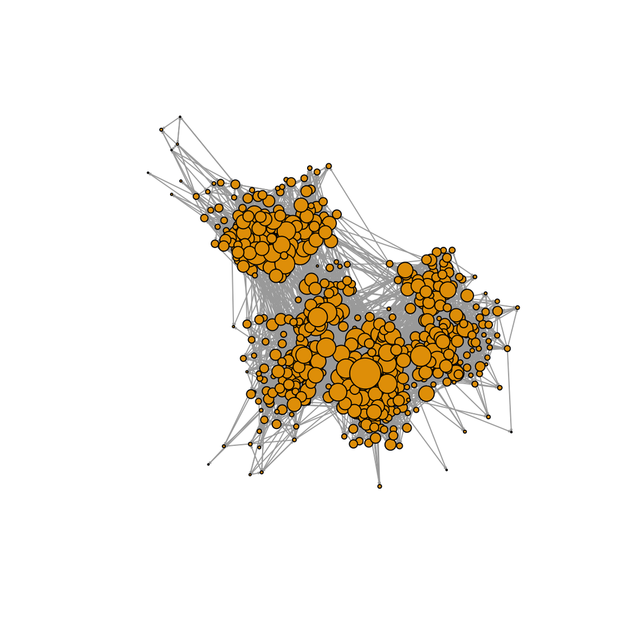

### Best friends

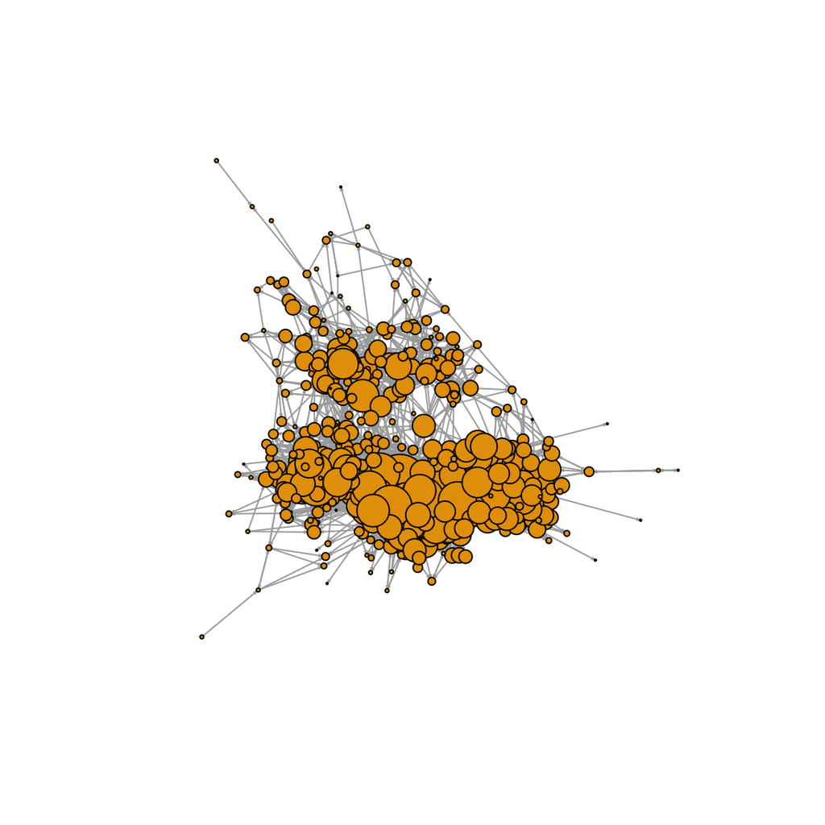

## Table and visualization of main metrics

Table summarizes network properties, plots show the 3 metrics that will later be used in the analyses: 1) In-degree, 2) Eigenvector Centrality, 3) Betweennes Centrality.

### Table

Network Summary

| Metric | GoodFriend | BestFriend |
| --- | --- | --- |
| Average degree | 14.53 | 8.49 |
| Average path length (largest component) | 3.25 | 8.76 |
| Degree (min - max) | 2 - 42 | 0 - 28 |
| Degree SD | 6.27 | 5.15 |
| Density | 0.026 | 0.015 |
| Diameter (largest component) | 7 | 26 |
| Largest component size | 562 | 555 |
| Number of components | 1 | 1 |
| Number of edges | 8165 | 4714 |
| Number of nodes | 562 | 555 |
| Reciprocity | 0.315 | 0.473 |

### Metrics Network Good Friends

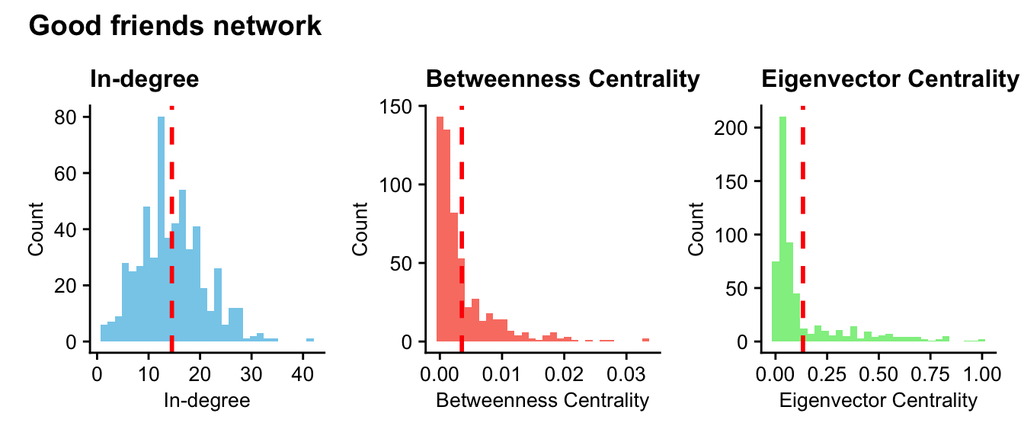

### Metrics Network Best Friends

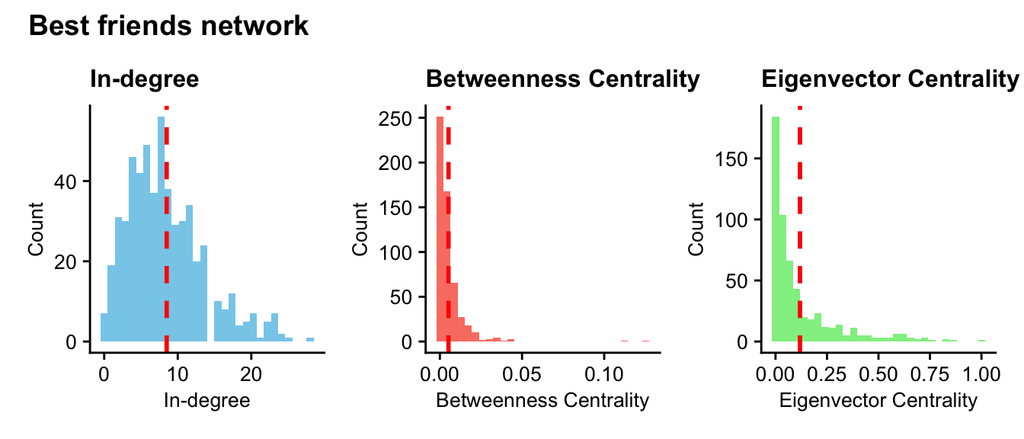

## 2. Analyses on participants who are in the experiment

I now examine the network metrics for participants included in the experimental dataset (i.e., the version that Catherine merged with the network data). This dataset contains participant IDs along with a wide range of network metrics associated with each individual. I assume these metrics were calculated based on the same network shown earlier, with the exception of participants who completed the social network questionnaire but did not fill out the punishment questionnaire.

Overall, the distributions of the metrics appear broadly similar to those previously shown. One notable difference is that the eigenvector centrality values in the merged dataset do not range between 0 and 1, as is typically expected. I am not sure how this version was computed—perhaps outliers were excluded or a different normalization method was applied—so it may be useful to compare alternative calculation approaches.

Another thing to note, is the the distribution of Eigenvector Centrality (EC) and Betweenness Centrality (BC) are quite skewed. This is to be expected, however it has some implications for the regression analyses, as there are not many individuals with high values of EC or BC, this may affect the results.

In other words, differences in network metrics are not experimentally manipulated, and thus it is harder to estimate differences in appropriatness ratings as a function of these metrics.

### Good friends network

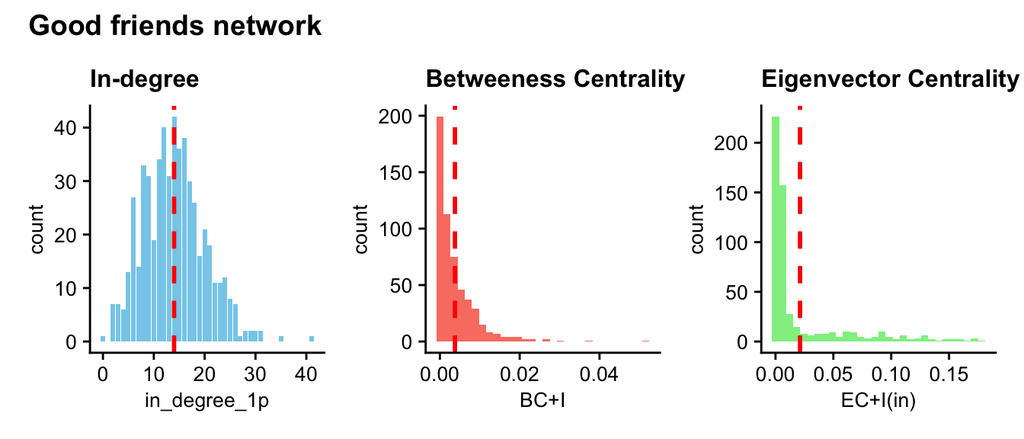

### Best Friends Network

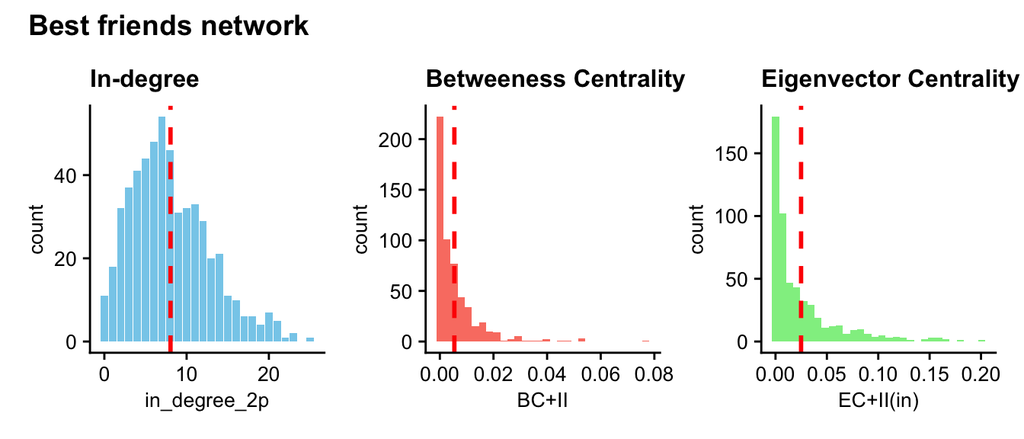

## 3. Regression analyses of appropriateness of violations

Using the above mentioned network metrics as independent variables, I now explore weather they are related to any difference in the appropriate ratings for 1) **violations** and 2) **punishment of violations**, in the two treatments (friends vs. non-friends). Let’s start with violations.

## 3.1 Appropriateness ratings of violations by network measures

I will start with a simple regression of rating ~ [network metric].

I will use both metrics from the “good-friends” and the “best-friends” social networks. In-degree metrics were standardized for easier interpretation.

The only significant predictors of appropriateness ratings are **in-degree** and **eigenvector** centrality, both with a positive effect.

This means that participants who are more central rated violations as more appropriate.

### In-degree [Good-friends]

|  | rating |  |  |
| --- | --- | --- | --- |
| Predictors | Estimates | CI | p |
| (Intercept) | 1.15 | 1.08 – 1.21 | **<0.001** |
| std in degree 1p | 0.08 | 0.02 – 0.15 | **0.012** |
| Random Effects |  |  |  |
| σ<sup>2</sup> | 1.25 |  |  |
| τ<sub>00</sub> <sub>ID2</sub> | 0.27 |  |  |
| ICC | 0.17 |  |  |
| N <sub>ID2</sub> | 494 |  |  |
| Observations | 2433 |  |  |
| Marginal R<sup>2</sup> / Conditional R<sup>2</sup> | 0.004 / 0.179 |  |  |

### In-degree [Best-friends]

|  | rating |  |  |
| --- | --- | --- | --- |
| Predictors | Estimates | CI | p |
| (Intercept) | 1.15 | 1.08 – 1.21 | **<0.001** |
| std in degree 2p | -0.02 | -0.09 – 0.04 | 0.493 |
| Random Effects |  |  |  |
| σ<sup>2</sup> | 1.25 |  |  |
| τ<sub>00</sub> <sub>ID2</sub> | 0.27 |  |  |
| ICC | 0.18 |  |  |
| N <sub>ID2</sub> | 494 |  |  |
| Observations | 2433 |  |  |
| Marginal R<sup>2</sup> / Conditional R<sup>2</sup> | 0.000 / 0.179 |  |  |

### In-degree [Enemies]

|  | rating |  |  |
| --- | --- | --- | --- |
| Predictors | Estimates | CI | p |
| (Intercept) | 1.14 | 1.06 – 1.22 | **<0.001** |
| in degree 2n | 0.01 | -0.03 – 0.05 | 0.608 |
| Random Effects |  |  |  |
| σ<sup>2</sup> | 1.25 |  |  |
| τ<sub>00</sub> <sub>ID2</sub> | 0.27 |  |  |
| ICC | 0.18 |  |  |
| N <sub>ID2</sub> | 494 |  |  |
| Observations | 2433 |  |  |
| Marginal R<sup>2</sup> / Conditional R<sup>2</sup> | 0.000 / 0.179 |  |  |

### Betweeness Centrality [Good-friends]

|  | rating |  |  |
| --- | --- | --- | --- |
| Predictors | Estimates | CI | p |
| (Intercept) | 1.13 | 1.05 – 1.21 | **<0.001** |
| BC1 | 4.13 | -7.69 – 15.94 | 0.494 |
| Random Effects |  |  |  |
| σ<sup>2</sup> | 1.25 |  |  |
| τ<sub>00</sub> <sub>ID2</sub> | 0.27 |  |  |
| ICC | 0.18 |  |  |
| N <sub>ID2</sub> | 494 |  |  |
| Observations | 2433 |  |  |
| Marginal R<sup>2</sup> / Conditional R<sup>2</sup> | 0.000 / 0.179 |  |  |

### Betweeness Centrality [Best-friends]

|  | rating |  |  |
| --- | --- | --- | --- |
| Predictors | Estimates | CI | p |
| (Intercept) | 1.12 | 1.05 – 1.20 | **<0.001** |
| BC2 | 4.52 | -2.87 – 11.91 | 0.231 |
| Random Effects |  |  |  |
| σ<sup>2</sup> | 1.25 |  |  |
| τ<sub>00</sub> <sub>ID2</sub> | 0.27 |  |  |
| ICC | 0.18 |  |  |
| N <sub>ID2</sub> | 494 |  |  |
| Observations | 2433 |  |  |
| Marginal R<sup>2</sup> / Conditional R<sup>2</sup> | 0.001 / 0.178 |  |  |

### Eigenvector Centrality [Good-friends]

|  | rating |  |  |
| --- | --- | --- | --- |
| Predictors | Estimates | CI | p |
| (Intercept) | 1.07 | 1.00 – 1.15 | **<0.001** |
| EC1 | 3.34 | 1.69 – 4.99 | **<0.001** |
| Random Effects |  |  |  |
| σ<sup>2</sup> | 1.25 |  |  |
| τ<sub>00</sub> <sub>ID2</sub> | 0.25 |  |  |
| ICC | 0.17 |  |  |
| N <sub>ID2</sub> | 494 |  |  |
| Observations | 2433 |  |  |
| Marginal R<sup>2</sup> / Conditional R<sup>2</sup> | 0.011 / 0.178 |  |  |

### new centrality

|  | rating |  |  |
| --- | --- | --- | --- |
| Predictors | Estimates | CI | p |
| (Intercept) | 1.15 | 1.08 – 1.21 | **<0.001** |
| std net indegree12 | 0.06 | -0.01 – 0.12 | 0.079 |
| Random Effects |  |  |  |
| σ<sup>2</sup> | 1.25 |  |  |
| τ<sub>00</sub> <sub>ID2</sub> | 0.27 |  |  |
| ICC | 0.18 |  |  |
| N <sub>ID2</sub> | 494 |  |  |
| Observations | 2433 |  |  |
| Marginal R<sup>2</sup> / Conditional R<sup>2</sup> | 0.002 / 0.179 |  |  |

## 3.2 Appropriateness ratings by network measures and treatment

I now include treatment (friend vs. non-friend) as an interaction in the regression model, which becomes rating ~ [network metric] * treatment. *The reference level for treatmetn is non-friend, for this and all the regressions below.*

We again see a main effect of in-degree and Eigenvector Centrality (of the “Good-Friends network) and a main effect of treatment, as we saw in the analyses without network properties. However, there are no significant interactions between network metrics and treatments.

This means that ratings of approppriateness of a violation of a friend vs. a non-friend were not related with the centrality of the rater.

### In-degree [Good-friends]

|  | rating |  |  |
| --- | --- | --- | --- |
| Predictors | Estimates | CI | p |
| (Intercept) | 0.88 | 0.68 – 1.08 | **<0.001** |
| in degree 1p | 0.01 | 0.00 – 0.03 | **0.036** |
| treatmentf | 0.14 | -0.09 – 0.37 | 0.232 |
| in degree 1p × treatmentf | -0.00 | -0.02 – 0.01 | 0.953 |
| Random Effects |  |  |  |
| σ<sup>2</sup> | 1.25 |  |  |
| τ<sub>00</sub> <sub>ID2</sub> | 0.26 |  |  |
| ICC | 0.18 |  |  |
| N <sub>ID2</sub> | 494 |  |  |
| Observations | 2433 |  |  |
| Marginal R<sup>2</sup> / Conditional R<sup>2</sup> | 0.007 / 0.181 |  |  |

### In-degree [Best-friends]

|  | rating |  |  |
| --- | --- | --- | --- |
| Predictors | Estimates | CI | p |
| (Intercept) | 1.08 | 1.00 – 1.16 | **<0.001** |
| std in degree 2p | -0.03 | -0.11 – 0.05 | 0.412 |
| treatmentf | 0.13 | 0.04 – 0.22 | **0.003** |
| std in degree 2p × treatmentf | 0.02 | -0.07 – 0.11 | 0.644 |
| Random Effects |  |  |  |
| σ<sup>2</sup> | 1.25 |  |  |
| τ<sub>00</sub> <sub>ID2</sub> | 0.27 |  |  |
| ICC | 0.18 |  |  |
| N <sub>ID2</sub> | 494 |  |  |
| Observations | 2433 |  |  |
| Marginal R<sup>2</sup> / Conditional R<sup>2</sup> | 0.003 / 0.181 |  |  |

### Betweeness Centrality [Good-friends]

|  | rating |  |  |
| --- | --- | --- | --- |
| Predictors | Estimates | CI | p |
| (Intercept) | 1.07 | 0.97 – 1.17 | **<0.001** |
| BC1 | 3.04 | -11.29 – 17.37 | 0.678 |
| treatmentf | 0.13 | 0.02 – 0.24 | **0.026** |
| BC1 × treatmentf | 2.13 | -14.44 – 18.69 | 0.801 |
| Random Effects |  |  |  |
| σ<sup>2</sup> | 1.25 |  |  |
| τ<sub>00</sub> <sub>ID2</sub> | 0.27 |  |  |
| ICC | 0.18 |  |  |
| N <sub>ID2</sub> | 494 |  |  |
| Observations | 2433 |  |  |
| Marginal R<sup>2</sup> / Conditional R<sup>2</sup> | 0.003 / 0.181 |  |  |

### Betweeness Centrality [Best-friends]

|  | rating |  |  |
| --- | --- | --- | --- |
| Predictors | Estimates | CI | p |
| (Intercept) | 1.07 | 0.97 – 1.16 | **<0.001** |
| BC2 | 2.45 | -6.41 – 11.31 | 0.588 |
| treatmentf | 0.11 | 0.00 – 0.22 | **0.043** |
| BC2 × treatmentf | 4.45 | -5.93 – 14.83 | 0.401 |
| Random Effects |  |  |  |
| σ<sup>2</sup> | 1.25 |  |  |
| τ<sub>00</sub> <sub>ID2</sub> | 0.27 |  |  |
| ICC | 0.18 |  |  |
| N <sub>ID2</sub> | 494 |  |  |
| Observations | 2433 |  |  |
| Marginal R<sup>2</sup> / Conditional R<sup>2</sup> | 0.004 / 0.181 |  |  |

### Eigenvector Centrality [Good-friends]

|  | rating |  |  |
| --- | --- | --- | --- |
| Predictors | Estimates | CI | p |
| (Intercept) | 1.00 | 0.91 – 1.09 | **<0.001** |
| EC1 | 3.40 | 1.39 – 5.41 | **0.001** |
| treatmentf | 0.14 | 0.03 – 0.24 | **0.009** |
| EC1 × treatmentf | -0.11 | -2.45 – 2.24 | 0.930 |
| Random Effects |  |  |  |
| σ<sup>2</sup> | 1.25 |  |  |
| τ<sub>00</sub> <sub>ID2</sub> | 0.25 |  |  |
| ICC | 0.17 |  |  |
| N <sub>ID2</sub> | 494 |  |  |
| Observations | 2433 |  |  |
| Marginal R<sup>2</sup> / Conditional R<sup>2</sup> | 0.014 / 0.181 |  |  |

### Eigenvector Centrality [Best-friends]

|  | rating |  |  |
| --- | --- | --- | --- |
| Predictors | Estimates | CI | p |
| (Intercept) | 1.11 | 1.02 – 1.21 | **<0.001** |
| EC2 | -1.32 | -3.53 – 0.89 | 0.243 |
| treatmentf | 0.12 | 0.01 – 0.24 | **0.027** |
| EC2 × treatmentf | 0.40 | -2.16 – 2.95 | 0.761 |
| Random Effects |  |  |  |
| σ<sup>2</sup> | 1.25 |  |  |
| τ<sub>00</sub> <sub>ID2</sub> | 0.27 |  |  |
| ICC | 0.18 |  |  |
| N <sub>ID2</sub> | 494 |  |  |
| Observations | 2433 |  |  |
| Marginal R<sup>2</sup> / Conditional R<sup>2</sup> | 0.004 / 0.181 |  |  |

### Combined score: 12

|  | rating |  |  |
| --- | --- | --- | --- |
| Predictors | Estimates | CI | p |
| (Intercept) | 1.05 | 0.93 – 1.18 | **<0.001** |
| net indegree12 | 0.01 | -0.00 – 0.02 | 0.079 |
| Random Effects |  |  |  |
| σ<sup>2</sup> | 1.25 |  |  |
| τ<sub>00</sub> <sub>ID2</sub> | 0.27 |  |  |
| ICC | 0.18 |  |  |
| N <sub>ID2</sub> | 494 |  |  |
| Observations | 2433 |  |  |
| Marginal R<sup>2</sup> / Conditional R<sup>2</sup> | 0.002 / 0.179 |  |  |

### Combined score: 22

[output not shown]

## 4. Regression analyses of appropriateness of punishment

I now turn to the appropriateness of punishment. Remember here that the rater is not the one to perform the punishment, but rather they are rating how appropriate it is for a friend, to punish a friend/non-friends.

## 4.1 Appropriatness of punishment by network measures

First I only look at appropriateness of punishment as a function of network metrics.

### In-degree [Good-friends]

|  | rating |  |  |
| --- | --- | --- | --- |
| Predictors | Estimates | CI | p |
| (Intercept) | 2.54 | 2.49 – 2.59 | **<0.001** |
| std in degree 1p | 0.04 | -0.02 – 0.09 | 0.168 |
| Random Effects |  |  |  |
| σ<sup>2</sup> | 1.56 |  |  |
| τ<sub>00</sub> <sub>ID2</sub> | 0.23 |  |  |
| ICC | 0.13 |  |  |
| N <sub>ID2</sub> | 494 |  |  |
| Observations | 7264 |  |  |
| Marginal R<sup>2</sup> / Conditional R<sup>2</sup> | 0.001 / 0.130 |  |  |

### In-degree [Best-friends]

|  | rating |  |  |
| --- | --- | --- | --- |
| Predictors | Estimates | CI | p |
| (Intercept) | 2.54 | 2.49 – 2.59 | **<0.001** |
| std in degree 2p | 0.01 | -0.04 – 0.06 | 0.641 |
| Random Effects |  |  |  |
| σ<sup>2</sup> | 1.56 |  |  |
| τ<sub>00</sub> <sub>ID2</sub> | 0.23 |  |  |
| ICC | 0.13 |  |  |
| N <sub>ID2</sub> | 494 |  |  |
| Observations | 7264 |  |  |
| Marginal R<sup>2</sup> / Conditional R<sup>2</sup> | 0.000 / 0.130 |  |  |

### Betweenness Centrality [Good-Friends]

|  | rating |  |  |
| --- | --- | --- | --- |
| Predictors | Estimates | CI | p |
| (Intercept) | 2.54 | 2.47 – 2.60 | **<0.001** |
| BC1 | 0.04 | -9.45 – 9.52 | 0.994 |
| Random Effects |  |  |  |
| σ<sup>2</sup> | 1.56 |  |  |
| τ<sub>00</sub> <sub>ID2</sub> | 0.23 |  |  |
| ICC | 0.13 |  |  |
| N <sub>ID2</sub> | 494 |  |  |
| Observations | 7264 |  |  |
| Marginal R<sup>2</sup> / Conditional R<sup>2</sup> | 0.000 / 0.130 |  |  |

### Betweenness Centrality [Best-Friends]

|  | rating |  |  |
| --- | --- | --- | --- |
| Predictors | Estimates | CI | p |
| (Intercept) | 2.52 | 2.45 – 2.58 | **<0.001** |
| BC2 | 4.06 | -1.87 – 9.99 | 0.179 |
| Random Effects |  |  |  |
| σ<sup>2</sup> | 1.56 |  |  |
| τ<sub>00</sub> <sub>ID2</sub> | 0.23 |  |  |
| ICC | 0.13 |  |  |
| N <sub>ID2</sub> | 494 |  |  |
| Observations | 7264 |  |  |
| Marginal R<sup>2</sup> / Conditional R<sup>2</sup> | 0.001 / 0.130 |  |  |

### Eigenvector Centrality [Good-Friends]

|  | rating |  |  |
| --- | --- | --- | --- |
| Predictors | Estimates | CI | p |
| (Intercept) | 2.51 | 2.45 – 2.57 | **<0.001** |
| EC1 | 1.16 | -0.18 – 2.51 | 0.090 |
| Random Effects |  |  |  |
| σ<sup>2</sup> | 1.56 |  |  |
| τ<sub>00</sub> <sub>ID2</sub> | 0.23 |  |  |
| ICC | 0.13 |  |  |
| N <sub>ID2</sub> | 494 |  |  |
| Observations | 7264 |  |  |
| Marginal R<sup>2</sup> / Conditional R<sup>2</sup> | 0.001 / 0.130 |  |  |

### Eigenvector Centrality [Best-Friends]

|  | rating |  |  |
| --- | --- | --- | --- |
| Predictors | Estimates | CI | p |
| (Intercept) | 2.56 | 2.49 – 2.62 | **<0.001** |
| EC2 | -0.71 | -2.18 – 0.75 | 0.340 |
| Random Effects |  |  |  |
| σ<sup>2</sup> | 1.56 |  |  |
| τ<sub>00</sub> <sub>ID2</sub> | 0.23 |  |  |
| ICC | 0.13 |  |  |
| N <sub>ID2</sub> | 494 |  |  |
| Observations | 7264 |  |  |
| Marginal R<sup>2</sup> / Conditional R<sup>2</sup> | 0.000 / 0.130 |  |  |

### Combined score: 12

|  | rating |  |  |
| --- | --- | --- | --- |
| Predictors | Estimates | CI | p |
| (Intercept) | 2.47 | 2.37 – 2.57 | **<0.001** |
| net indegree12 | 0.01 | -0.00 – 0.01 | 0.132 |
| Random Effects |  |  |  |
| σ<sup>2</sup> | 1.56 |  |  |
| τ<sub>00</sub> <sub>ID2</sub> | 0.23 |  |  |
| ICC | 0.13 |  |  |
| N <sub>ID2</sub> | 494 |  |  |
| Observations | 7264 |  |  |
| Marginal R<sup>2</sup> / Conditional R<sup>2</sup> | 0.001 / 0.130 |  |  |

### Combined score: 22

|  | rating |  |  |
| --- | --- | --- | --- |
| Predictors | Estimates | CI | p |
| (Intercept) | 2.47 | 2.36 – 2.59 | **<0.001** |
| net indegree22 | 0.00 | -0.00 – 0.01 | 0.203 |
| Random Effects |  |  |  |
| σ<sup>2</sup> | 1.56 |  |  |
| τ<sub>00</sub> <sub>ID2</sub> | 0.23 |  |  |
| ICC | 0.13 |  |  |
| N <sub>ID2</sub> | 494 |  |  |
| Observations | 7264 |  |  |
| Marginal R<sup>2</sup> / Conditional R<sup>2</sup> | 0.001 / 0.130 |  |  |

## 4.2 Appropriateness of punishment by network metrics * treatment

I now include treatment interactions, so again the regression is rating ~ [metric] * treatment.

There are no significant interaction effects, even for Eigenvector Centrality.

This means that ratings across the two treatments were not affected by individuals’s network position.

### In-degree [Good-Friends]

|  | rating |  |  |
| --- | --- | --- | --- |
| Predictors | Estimates | CI | p |
| (Intercept) | 2.54 | 2.48 – 2.60 | **<0.001** |
| std in degree 1p | 0.05 | -0.01 – 0.11 | 0.093 |
| treatmentf | -0.00 | -0.06 – 0.06 | 0.977 |
| std in degree 1p × treatmentf | -0.03 | -0.09 – 0.03 | 0.333 |
| Random Effects |  |  |  |
| σ<sup>2</sup> | 1.56 |  |  |
| τ<sub>00</sub> <sub>ID2</sub> | 0.23 |  |  |
| ICC | 0.13 |  |  |
| N <sub>ID2</sub> | 494 |  |  |
| Observations | 7264 |  |  |
| Marginal R<sup>2</sup> / Conditional R<sup>2</sup> | 0.001 / 0.130 |  |  |

### In-degree [Best-Friends]

|  | rating |  |  |
| --- | --- | --- | --- |
| Predictors | Estimates | CI | p |
| (Intercept) | 2.54 | 2.48 – 2.60 | **<0.001** |
| std in degree 2p | 0.04 | -0.02 – 0.10 | 0.231 |
| treatmentf | -0.00 | -0.06 – 0.06 | 0.997 |
| std in degree 2p × treatmentf | -0.05 | -0.11 – 0.01 | 0.109 |
| Random Effects |  |  |  |
| σ<sup>2</sup> | 1.56 |  |  |
| τ<sub>00</sub> <sub>ID2</sub> | 0.23 |  |  |
| ICC | 0.13 |  |  |
| N <sub>ID2</sub> | 494 |  |  |
| Observations | 7264 |  |  |
| Marginal R<sup>2</sup> / Conditional R<sup>2</sup> | 0.000 / 0.130 |  |  |

### Betweeness Centrality [Good-Friends]

|  | rating |  |  |
| --- | --- | --- | --- |
| Predictors | Estimates | CI | p |
| (Intercept) | 2.53 | 2.46 – 2.60 | **<0.001** |
| BC1 | 2.74 | -8.11 – 13.60 | 0.620 |
| treatmentf | 0.02 | -0.05 – 0.09 | 0.587 |
| BC1 × treatmentf | -5.50 | -16.25 – 5.25 | 0.316 |
| Random Effects |  |  |  |
| σ<sup>2</sup> | 1.56 |  |  |
| τ<sub>00</sub> <sub>ID2</sub> | 0.23 |  |  |
| ICC | 0.13 |  |  |
| N <sub>ID2</sub> | 494 |  |  |
| Observations | 7264 |  |  |
| Marginal R<sup>2</sup> / Conditional R<sup>2</sup> | 0.000 / 0.130 |  |  |

### Betweeness Centrality [Best-Friends]

|  | rating |  |  |
| --- | --- | --- | --- |
| Predictors | Estimates | CI | p |
| (Intercept) | 2.52 | 2.45 – 2.59 | **<0.001** |
| BC2 | 4.27 | -2.46 – 11.00 | 0.213 |
| treatmentf | 0.00 | -0.07 – 0.07 | 0.983 |
| BC2 × treatmentf | -0.45 | -7.19 – 6.29 | 0.896 |
| Random Effects |  |  |  |
| σ<sup>2</sup> | 1.56 |  |  |
| τ<sub>00</sub> <sub>ID2</sub> | 0.23 |  |  |
| ICC | 0.13 |  |  |
| N <sub>ID2</sub> | 494 |  |  |
| Observations | 7264 |  |  |
| Marginal R<sup>2</sup> / Conditional R<sup>2</sup> | 0.001 / 0.130 |  |  |

### Eigenvector Centrality [Good-Friends]

|  | rating |  |  |
| --- | --- | --- | --- |
| Predictors | Estimates | CI | p |
| (Intercept) | 2.52 | 2.45 – 2.59 | **<0.001** |
| EC1 | 0.99 | -0.54 – 2.53 | 0.205 |
| treatmentf | -0.01 | -0.08 – 0.06 | 0.784 |
| EC1 × treatmentf | 0.35 | -1.18 – 1.87 | 0.656 |
| Random Effects |  |  |  |
| σ<sup>2</sup> | 1.56 |  |  |
| τ<sub>00</sub> <sub>ID2</sub> | 0.23 |  |  |
| ICC | 0.13 |  |  |
| N <sub>ID2</sub> | 494 |  |  |
| Observations | 7264 |  |  |
| Marginal R<sup>2</sup> / Conditional R<sup>2</sup> | 0.001 / 0.130 |  |  |

### Eigenvector Centrality [Best-Friends]

|  | rating |  |  |
| --- | --- | --- | --- |
| Predictors | Estimates | CI | p |
| (Intercept) | 2.55 | 2.47 – 2.62 | **<0.001** |
| EC2 | -0.23 | -1.90 – 1.45 | 0.790 |
| treatmentf | 0.02 | -0.05 – 0.09 | 0.531 |
| EC2 × treatmentf | -0.98 | -2.64 – 0.68 | 0.246 |
| Random Effects |  |  |  |
| σ<sup>2</sup> | 1.56 |  |  |
| τ<sub>00</sub> <sub>ID2</sub> | 0.23 |  |  |
| ICC | 0.13 |  |  |
| N <sub>ID2</sub> | 494 |  |  |
| Observations | 7264 |  |  |
| Marginal R<sup>2</sup> / Conditional R<sup>2</sup> | 0.001 / 0.130 |  |  |

## 5. 3-way interaction

Very exploratively, I add the scenarios’ domain as an additional interaction term.

|  | rating |  |  |
| --- | --- | --- | --- |
| Predictors | Estimates | CI | p |
| (Intercept) | 2.60 | 2.47 – 2.72 | **<0.001** |
| EC1 | 0.85 | -1.83 – 3.52 | 0.535 |
| treatmentf | 0.00 | -0.18 – 0.18 | 1.000 |
| domain [interrupt] | -0.22 | -0.40 – -0.05 | **0.014** |
| domain [online] | -0.14 | -0.29 – 0.00 | 0.057 |
| domain [stealing] | 0.33 | 0.15 – 0.50 | **<0.001** |
| domain [texting] | -0.41 | -0.56 – -0.27 | **<0.001** |
| EC1 × treatmentf | -0.07 | -4.09 – 3.96 | 0.975 |
| EC1 × domain [interrupt] | 0.88 | -3.13 – 4.89 | 0.667 |
| EC1 × domain [online] | 0.08 | -3.04 – 3.20 | 0.962 |
| EC1 × domain [stealing] | 1.38 | -2.62 – 5.38 | 0.500 |
| EC1 × domain [texting] | -0.58 | -3.69 – 2.53 | 0.716 |
| treatmentf × domain [interrupt] | -0.02 | -0.31 – 0.26 | 0.867 |
| treatmentf × domain [online] | 0.19 | -0.01 – 0.40 | 0.069 |
| treatmentf × domain [stealing] | -0.05 | -0.34 – 0.23 | 0.709 |
| treatmentf × domain [texting] | -0.10 | -0.31 – 0.10 | 0.333 |
| (EC1 × treatmentf) × domain [interrupt] | 0.93 | -5.60 – 7.46 | 0.780 |
| (EC1 × treatmentf) × domain [online] | -1.41 | -6.10 – 3.29 | 0.558 |
| (EC1 × treatmentf) × domain [stealing] | -0.70 | -7.22 – 5.82 | 0.834 |
| (EC1 × treatmentf) × domain [texting] | 1.57 | -3.12 – 6.25 | 0.512 |
| Random Effects |  |  |  |
| σ<sup>2</sup> | 1.49 |  |  |
| τ<sub>00</sub> <sub>ID2</sub> | 0.24 |  |  |
| ICC | 0.14 |  |  |
| N <sub>ID2</sub> | 494 |  |  |
| Observations | 7264 |  |  |
| Marginal R<sup>2</sup> / Conditional R<sup>2</sup> | 0.040 / 0.171 |  |  |

## 6. Visualization of main regression results

Overall, results were quite small and the EC ones should be interpret carefully given that EC is not normally/uniformely distributed across participants, thus estimates may be quite unreliable. To give an idea, I am plotting the relationships between variables that turned out to be significant.

### Violation rating ~ In-degree

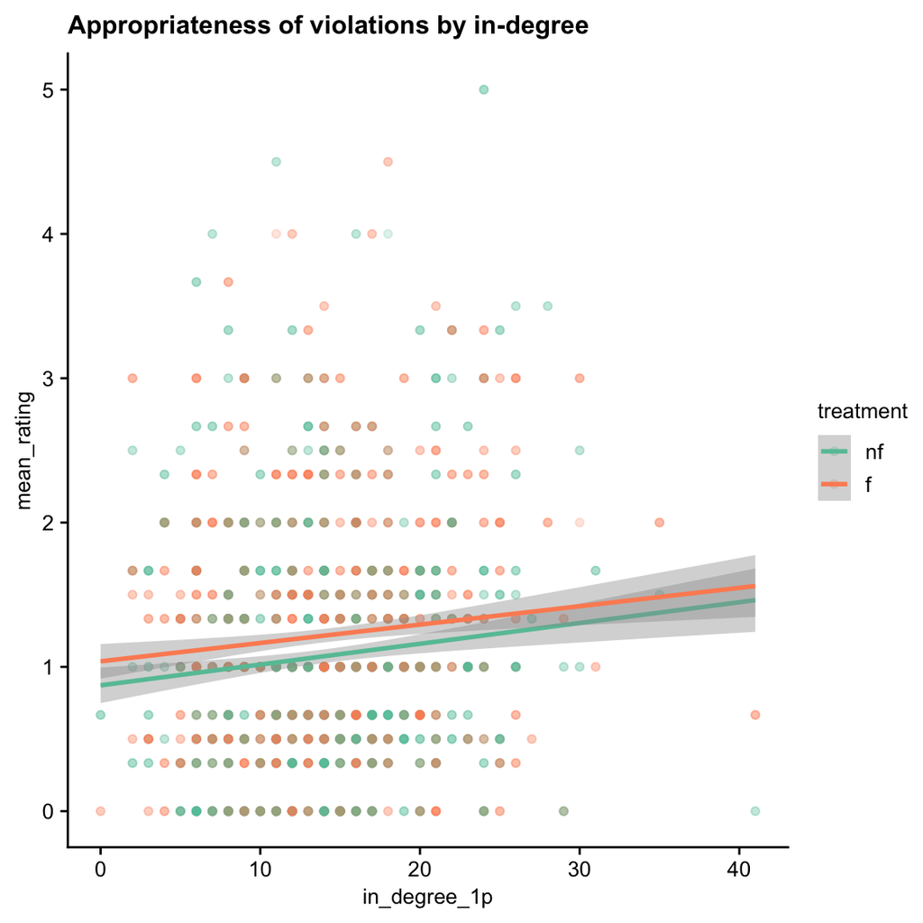

The higher participants’ in degree, the higher the appropriateness rating. Ratings are averaged across the 5 domains for each participants: Each dot is 1 participant in 1 treatment (nf = non-friend, f = friend)

### Violation rating ~ Eigenvector Centrality

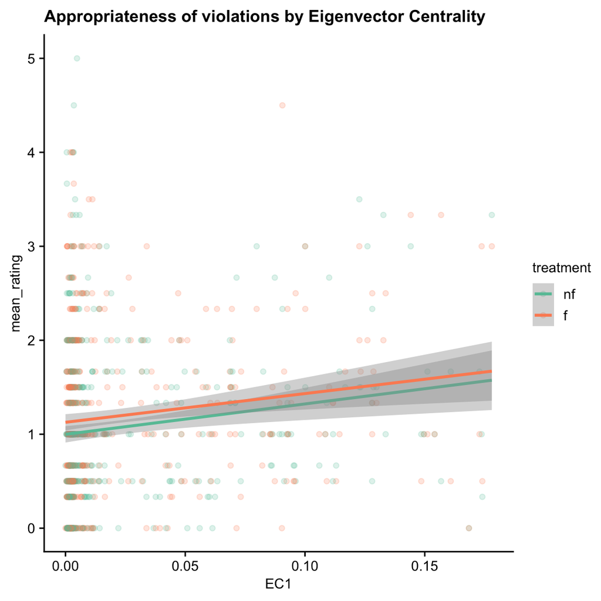

The higher participants’ Eigenvector Centrality, the higher the appropriateness rating. Ratings are averaged across the 5 domains for each participants: Each dot is 1 participant in 1 treatment (nf = non-friend, f = friend). Note that most participants are between 0 and 0.02

### Punishment Rating ~ Eigenvector Centrality

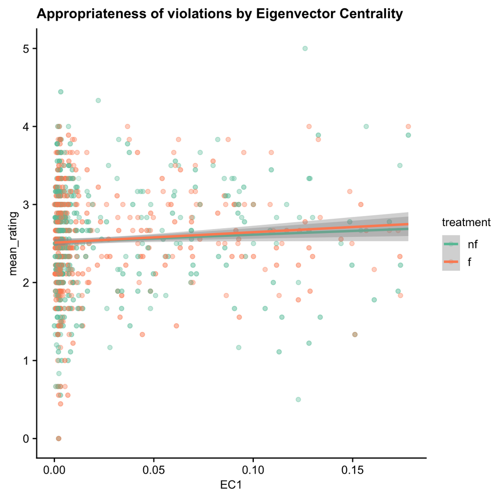

### Punishment Rating ~ Eigenvector Centrality * Treatment * Domain

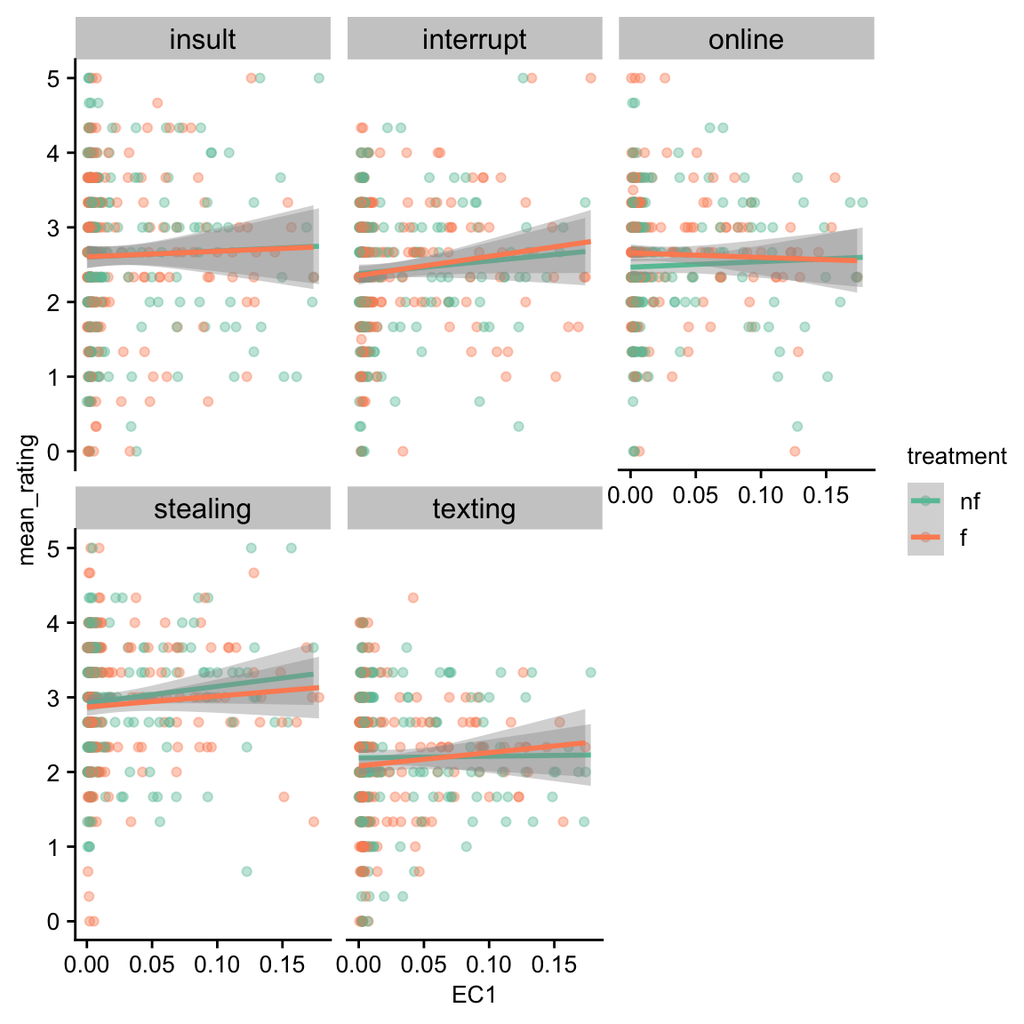